# Psych 254 W15 PS #1

Yuan Chang Leong

January 12, 2015

First, we clear the workspace and load in some useful helper code.

```r
rm(list=ls())
source("../helper/useful.R")
```

## Part 1: Data cleaning

Before we load the data in R, let’s take a look at it in excel. We see that there are unnecessary columns. Let’s *keep only the relevant columns*, which are WorkerID, WorkTimeinSeconds, Input.condition, the three input prices and the three answer costs.

Next, we see that the numbers are not entered in consistent format. Let’s *remove the 1000 seperator* and *convert spelled numbers to numeric format*. We save the edited file as a new .csv, `janiszewski_rep_exercise_interim.csv`, load it in, and take a look using `head()` and `summary()`.

```r
d <- read.csv("../data/janiszewski_rep_exercise_interim.csv")
head(d)
```

```
##         WorkerId WorkTimeInSeconds Input.condition Input.price1
## 1 A18L9BY7DNA8D3                23            over         5012
## 2 A1YGOYNWW3Q9SQ               228            over         5012
## 3 A2JKCS6UCAUARS                89            over         5012
## 4 A3IM0Z8F01XLE6               145            over         5012
## 5 A21JRS3L6PMJ5Q               232            over         5012
## 6 A1ZLYD5GP1FLYL                86            over         5012
##   Input.price2 Input.price3 Answer.dog_cost Answer.plasma_cost
## 1         2508         9.36            2300               4800
## 2         2508         9.36            2450               4850
## 3         2508         9.36             800               1200
## 4         2508         9.36            2000               4200
## 5         2508         9.36            2000               4500
## 6         2508         9.36            1600               4600
##   Answer.sushi_cost
## 1               8.7
## 2               9.0
## 3               8.0
## 4               9.0
## 5               8.5
## 6               8.0
```

```r
summary(d)
```

```
##            WorkerId  WorkTimeInSeconds Input.condition  Input.price1
##  A1VYX5VKZ0CTWU: 3   Min.   : 18.0     over   :30      Min.   :4988
##  A5IUO2T5MZQUZ : 2   1st Qu.: 85.2     rounded:30      1st Qu.:4988
##  A10316ZXDCW4TT: 1   Median :113.0     under  :30      Median :5000
##  A14U5M64AK4MAR: 1   Mean   :122.0                     Mean   :5000
##  A16VNOCOSQS8H6: 1   3rd Qu.:155.5                     3rd Qu.:5012
##  A17FFPDVAJ2SQJ: 1   Max.   :284.0                     Max.   :5012
##  (Other)       :81
##   Input.price2   Input.price3  Answer.dog_cost Answer.plasma_cost
##  Min.   :2492   Min.   :8.64   Min.   : 500    Min.   :   0
##  1st Qu.:2492   1st Qu.:8.64   1st Qu.:1750    1st Qu.:3500
##  Median :2500   Median :9.00   Median :2000    Median :4500
##  Mean   :2500   Mean   :9.00   Mean   :1893    Mean   :4077
##  3rd Qu.:2508   3rd Qu.:9.36   3rd Qu.:2200    3rd Qu.:4700
##  Max.   :2508   Max.   :9.36   Max.   :2500    Max.   :5000
##
##  Answer.sushi_cost
##  Min.   :6.50
##  1st Qu.:7.56
##  Median :8.00
##  Mean   :7.99
##  3rd Qu.:8.50
##  Max.   :9.30
##  NA's   :1
```

We see that subjects `A1VYX5VKZ0CTWU` and `A5IUO2T5MZQUZ` did the study more than once. Let’s remove their data.

```r
d1 = filter(d, WorkerId != "A1VYX5VKZ0CTWU") %>%  filter(WorkerId != "A5IUO2T5MZQUZ")
summary(d1)
```

```
##            WorkerId  WorkTimeInSeconds Input.condition  Input.price1
##  A10316ZXDCW4TT: 1   Min.   : 18       over   :28      Min.   :4988
##  A14U5M64AK4MAR: 1   1st Qu.: 86       rounded:29      1st Qu.:4988
##  A16VNOCOSQS8H6: 1   Median :113       under  :28      Median :5000
##  A17FFPDVAJ2SQJ: 1   Mean   :125                       Mean   :5000
##  A18L9BY7DNA8D3: 1   3rd Qu.:156                       3rd Qu.:5012
##  A1A70X1I06UZKH: 1   Max.   :284                       Max.   :5012
##  (Other)       :79
##   Input.price2   Input.price3  Answer.dog_cost Answer.plasma_cost
##  Min.   :2492   Min.   :8.64   Min.   : 500    Min.   :   0
##  1st Qu.:2492   1st Qu.:8.64   1st Qu.:1790    1st Qu.:3800
##  Median :2500   Median :9.00   Median :2000    Median :4500
##  Mean   :2500   Mean   :9.00   Mean   :1900    Mean   :4094
##  3rd Qu.:2508   3rd Qu.:9.36   3rd Qu.:2200    3rd Qu.:4700
##  Max.   :2508   Max.   :9.36   Max.   :2500    Max.   :5000
##
##  Answer.sushi_cost
##  Min.   :6.50
##  1st Qu.:7.66
##  Median :8.00
##  Mean   :8.01
##  3rd Qu.:8.50
##  Max.   :9.30
##  NA's   :1
```

The dataset seems pretty reasonable now.

## Part 2: Making these data tidy

Now let’s start with the cleaned data, so that we are all beginning from the same place.

```r
d <- read.csv("../data/janiszewski_rep_cleaned.csv")
```

This data frame is in *wide* format - that means that each row is a participant and there are multiple observations per participant. This data is not *tidy*.

To make this data tidy, we’ll do some cleanup. First, we *remove the unnecessary columns* using the verb `select`.

```r
d.tidy <- select(d,WorkerId,WorkTimeInSeconds,starts_with("Input."),starts_with("Answer"))
```

Then we *rename* the columns to more sensible names.

```r
d.tidy <- d %>%
  select(WorkerId,
         WorkTimeInSeconds,
         starts_with("Input."),
         starts_with("Answer")) %>%
  rename(ID = WorkerId,
         RT = WorkTimeInSeconds,
         Condition = Input.condition,
         Input.Expensive = Input.price1,
         Input.Middle = Input.price2,
         Input.Cheap = Input.price3,
         Expensive = Answer.plasma_cost,
         Middle = Answer.dog_cost,
         Cheap = Answer.sushi_cost)

# Change column orders of expensive and middle so that it is more sensible
d.tidy = d.tidy[c(1:6,8,7,9)]
head(d.tidy)
```

```
##               ID  RT Condition Input.Expensive Input.Middle Input.Cheap
## 1 A18L9BY7DNA8D3  23      over            5012         2508        9.36
## 2 A1YGOYNWW3Q9SQ 228      over            5012         2508        9.36
## 3 A2JKCS6UCAUARS  89      over            5012         2508        9.36
## 4 A3IM0Z8F01XLE6 145      over            5012         2508        9.36
## 5 A21JRS3L6PMJ5Q 232      over            5012         2508        9.36
## 6 A1ZLYD5GP1FLYL  86      over            5012         2508        9.36
##   Expensive Middle Cheap
## 1      4800   2300   8.7
## 2      4850   2450   9.0
## 3      1200    800   8.0
## 4      4200   2000   9.0
## 5      4500   2000   8.5
## 6      4600   1600   8.0
```

We use the verb *gather* to turn this into a *tidy* data frame.

```r
d.tidy = d.tidy %>% gather("ItemType","Response",7:9)
head(d.tidy)
```

```
##               ID  RT Condition Input.Expensive Input.Middle Input.Cheap
## 1 A18L9BY7DNA8D3  23      over            5012         2508        9.36
## 2 A1YGOYNWW3Q9SQ 228      over            5012         2508        9.36
## 3 A2JKCS6UCAUARS  89      over            5012         2508        9.36
## 4 A3IM0Z8F01XLE6 145      over            5012         2508        9.36
## 5 A21JRS3L6PMJ5Q 232      over            5012         2508        9.36
## 6 A1ZLYD5GP1FLYL  86      over            5012         2508        9.36
##    ItemType Response
## 1 Expensive     4800
## 2 Expensive     4850
## 3 Expensive     1200
## 4 Expensive     4200
## 5 Expensive     4500
## 6 Expensive     4600
```

The dataset is now *tidy*.

Bonus problem: *spread* these data back into a wide format data frame.

```r
d.wide = spread(d.tidy,"ItemType", "Response")
head(d.wide)
```

```
##               ID  RT Condition Input.Expensive Input.Middle Input.Cheap
## 1 A10316ZXDCW4TT 181   rounded            5000         2500        9.00
## 2 A14U5M64AK4MAR  66     under            4988         2492        8.64
## 3 A16VNOCOSQS8H6 177     under            4988         2492        8.64
## 4 A17FFPDVAJ2SQJ  88      over            5012         2508        9.36
## 5 A18L9BY7DNA8D3  23      over            5012         2508        9.36
## 6 A1A70X1I06UZKH 194     under            4988         2492        8.64
##   Expensive Middle Cheap
## 1      4300   2000  8.25
## 2      3500   2100  6.99
## 3      2500   2000  7.80
## 4      4699   1875  7.89
## 5      4800   2300  8.70
## 6      4888   2192  7.50
```

## Part 3: Manipulating the data using dplyr

Try also using the dplyr `distinct` function to remove the duplicate participants from the raw csv file that you discovered in part 1.

```r
d.raw <- read.csv("../data/janiszewski_rep_exercise.csv")
d.unique.subs <- d.raw %>% distinct(WorkerId)
```

I should note that this method retains one of the datapoints from each of the duplicate participant. I would prefer to remove all instances of duplicate participants.

As we said in class, a good thing to do is always to check histograms of the response variable. Do that now, using either regular base graphics or ggplot. What can you conclude?

```
## stat_bin: binwidth defaulted to range/30. Use 'binwidth = x' to adjust this.
```

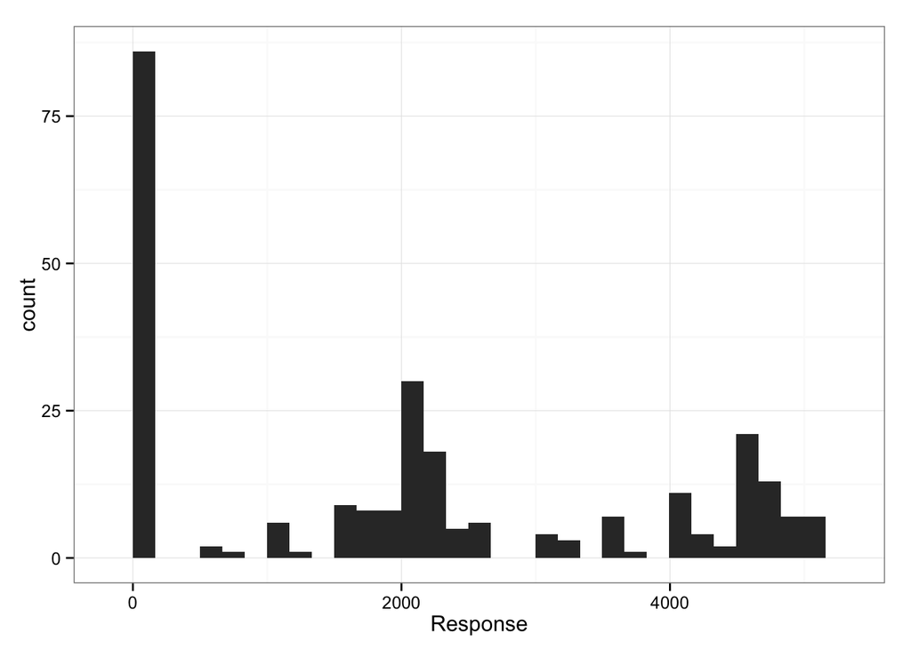

```r
# Plot histogram
qplot(Response, data=d.tidy, geom="histogram")
```

**There are three peaks in the histogram, probably because there were three items of very difference prices and the bets on each item clustered around each other.**

OK, now we turn to the actual data anlysis. We’ll be using dplyr verbs to `filter`, `group`,`mutate`, and `summarise` the data.

Start by using `summarise` on `d.tidy` to compute the mean bet across all participants. Note that this is simply taking the grand mean. Ultimately, we would like to compute the mean for different conditions and items, but this will come later. Right now we’re just learning the syntax of `summarise`.

```r
# Compute Grand Mean
summarise(d.tidy, mean(Response,na.rm = T))
```

```
##   mean(Response, na.rm = T)
## 1                      2023
```

Let’s use that capacity to combine `summarise` with `group_by`, which allows us to break up our summary into groups. Try grouping by item and condition and taking means using `summarise`, chaining these two verbs with `%>%`.

```r
d.tidy %>%
  group_by(ItemType, Condition) %>%
  summarise(mean(Response,na.rm =T))
```

```
## Source: local data frame [9 x 3]
## Groups: ItemType
##
##    ItemType Condition mean(Response, na.rm = T)
## 1 Expensive      over                  4300.333
## 2 Expensive   rounded                  4091.655
## 3 Expensive     under                  4018.357
## 4    Middle      over                  1898.300
## 5    Middle   rounded                  1884.482
## 6    Middle     under                  1906.964
## 7     Cheap      over                     8.322
## 8     Cheap   rounded                     7.956
## 9     Cheap     under                     7.742
```

OK, it’s looking like there are maybe some differences between conditions, but how are we going to plot these? They are fundamentally different magnitudes from one another.

Really we need the size of the deviation from the anchor, which means we need the anchor value (the `Input.price` variables that we’ve ignored up until now). Let’s go back to the data and add that in.

Take a look at this complex expression. You don’t have to modify it, but see what is being done here with gather, separate and spread. Run each part (e.g. the first verb, the first two verbs, etc.) and after doing each, look at `head(d.tidy)` to see what they do.

```r
d.tidy <- d %>%
  select(WorkerId, Input.condition,
         starts_with("Answer"),
         starts_with("Input")) %>%
  rename(workerid = WorkerId,
         condition = Input.condition,
         plasma_anchor = Input.price1,
         dog_anchor = Input.price2,
         sushi_anchor = Input.price3,
         dog_cost = Answer.dog_cost,
         plasma_cost = Answer.plasma_cost,
         sushi_cost = Answer.sushi_cost) %>%
  gather(name, cost,
         dog_anchor, plasma_anchor, sushi_anchor,
         dog_cost, plasma_cost, sushi_cost) %>%
  separate(name, c("item", "type"), sep = "_") %>%
  spread(type, cost)
```

Now we can do the same thing as before but look at the relative difference between anchor and estimate. Let’s do this two ways:

- By computing absolute value of percentage change in price, and
- By computing z-scores over items.

To do the first, use the `mutate` verb to add a percent change column, then comute the same summary as before.

```r
pcts <- d.tidy %>%
  mutate(pct_change = abs((cost - anchor))/anchor * 100) %>%
  group_by(item,condition) %>%
  summarise(pct = mean(pct_change,na.rm =T))
```

To do the second, you will need to `group` first by item, compute z-scores with respect to items, then further group by condition.

HINT: `scale(x)` returns a complicated data structure that doesn’t play nicely with dplyr. try `scale(x)[,1]` to get what you need.

HINT: by default, `group_by` undoes any previous groupings. If you want to add new grouping variables *on top* of pre-existing ones, specify `add = TRUE`, e.g., `d %>% group_by(var1) %>% group_by(var2, add = TRUE)`.

```r
z.scores <- d.tidy %>%
  group_by(item) %>%
  mutate(change = abs((cost - anchor))) %>%
  mutate(z = scale(change)[,1]) %>%
  group_by(condition, add = T) %>%
  summarise(z = mean(z,na.rm =T))
```

OK, now here comes the end: we’re going to plot the differences and see if anything happened. First the percent change:

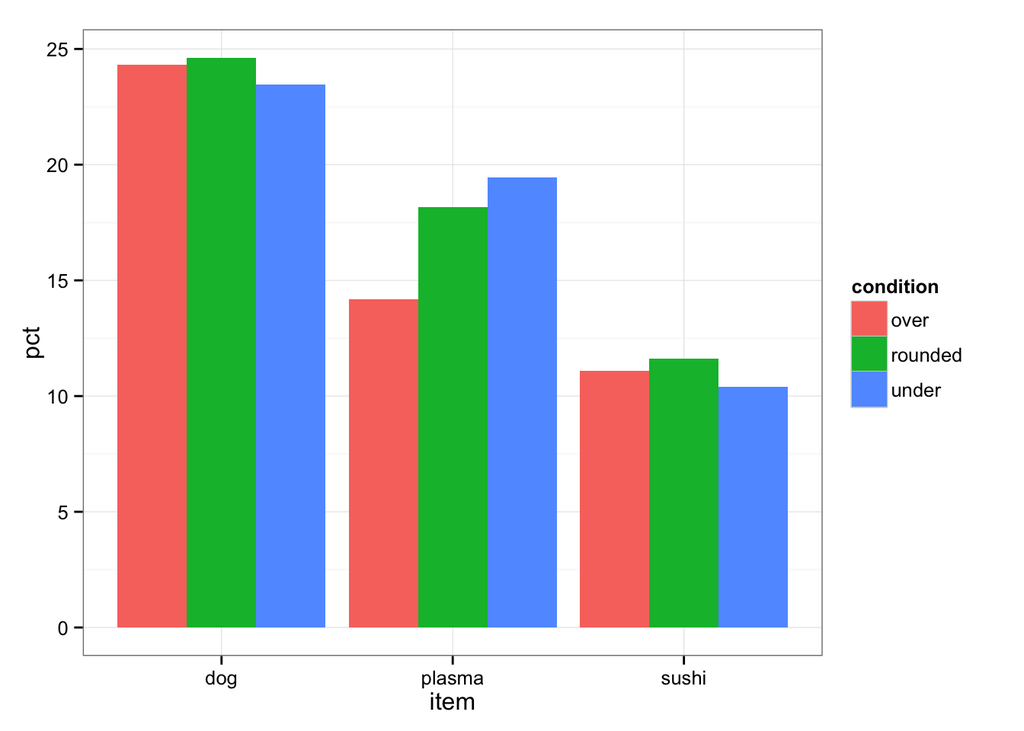

```r
qplot(item, pct, fill=condition,
      position="dodge",
      stat="identity", geom="bar",
      data=pcts)
```

and the z-scores:

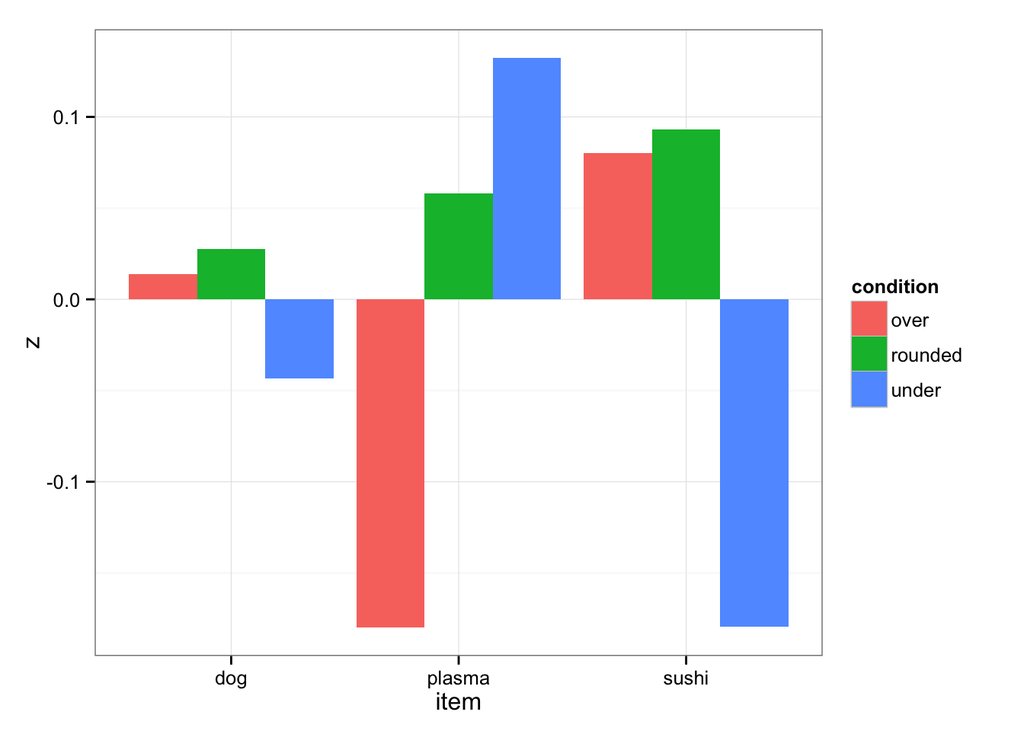

```r
qplot(item, z, fill=condition,
      position="dodge",
      stat="identity", geom="bar",
      data=z.scores)
```

We see that for the dog and sushi, there was indeed a greater adjustment away from a rounded anchor than precise anchors. However, for the plasma tv, participants adjusted more for the precise under anchor than the rounded anchor. Interestingly, adjustment was smallest for the precise under anchor for the other two items (dog and sushi).

Oh well. This replication didn’t seem to work out straightforwardly.